# Pronosticos_30_Mayo_Ibarra_Sergio_Colorado

Sergibar

2023-05-30

## UNAM Maestría en Ingeniería de Sistemas

## Dr. Jair Morales Camarena

## Alumno: Ibarra Ramírez Sergio

Importación de librerias necesarias para trabajar

```r
library(tidyverse)      # data manipulation and visualization
library(lubridate)      # easily work with dates and times
library(fpp2)           # working with time series data
library(zoo)
```

```r
library(ggplot2)
library(plyr)
library(dplyr)
library(knitr)
library(TTR)
library(hydroGOF)
```

# coloradoflow

### Importación de los datos de nuestra serie que se va a llamar datos_original

```r
library(readxl)
# Read the Excel file
colorado_datos_original <- read_excel('coloradoflow.xlsx')

# View the imported data
print(colorado_datos_original)
```

```
## # A tibble: 600 × 2
##        t     x
##    <dbl> <dbl>
##  1     1  0.46
##  2     2  0.53
##  3     3  1.24
##  4     4  1.48
##  5     5  3.69
##  6     6  4.57
##  7     7  2.58
##  8     8  0.69
##  9     9  0.5
## 10    10  1.4
## # … with 590 more rows
```

Nos aseguramos que la data se haya importado correctamente

```r
summary(colorado_datos_original)
```

```
##        t               x
##  Min.   :  1.0   Min.   :0.160
##  1st Qu.:150.8   1st Qu.:0.440
##  Median :300.5   Median :0.640
##  Mean   :300.5   Mean   :1.320
##  3rd Qu.:450.2   3rd Qu.:1.663
##  Max.   :600.0   Max.   :9.810
```

```r
typeof(colorado_datos_original)
```

```
## [1] "list"
```

```r
dim(colorado_datos_original)
```

```
## [1] 600   2
```

#### Convertimos los colorado_datos_original a Serie de tiempo

Al observar la data se determina que existe una especie de estacionalidad que se repite cada 12 meses

```r
colorado_datos_original_ts<- ts(colorado_datos_original$x, frequency = 12)
head(colorado_datos_original_ts)
```

```
##    Jan  Feb  Mar  Apr  May  Jun
## 1 0.46 0.53 1.24 1.48 3.69 4.57
```

```r
typeof(colorado_datos_original_ts)
```

```
## [1] "double"
```

Graficamos la serie del tiempo

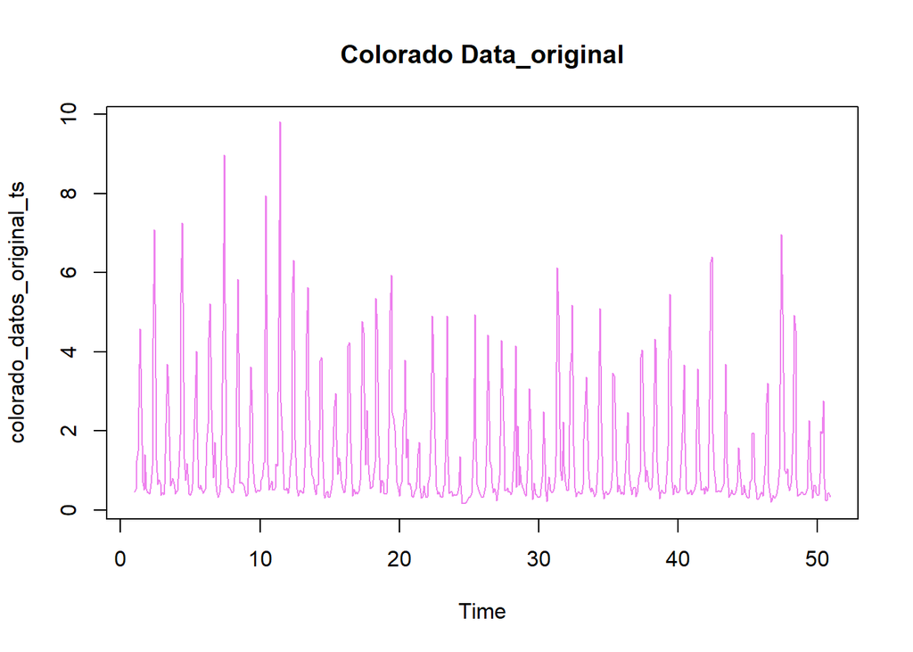

```r
plot(colorado_datos_original_ts, col = "violet", main = "Colorado Data_original")
```

### Vamos a descomponer la data usando el metodo decompose para entender sus compoentes de tren, seasonalidad y aleatorio

```r
colorado_datos_original_ts_decompose <- decompose(colorado_datos_original_ts)
summary(colorado_datos_original_ts_decompose)
```

```
##          Length Class  Mode
## x        600    ts     numeric
## seasonal 600    ts     numeric
## trend    600    ts     numeric
## random   600    ts     numeric
## figure    12    -none- numeric
## type       1    -none- character
```

Vamos a plotear la desmposición

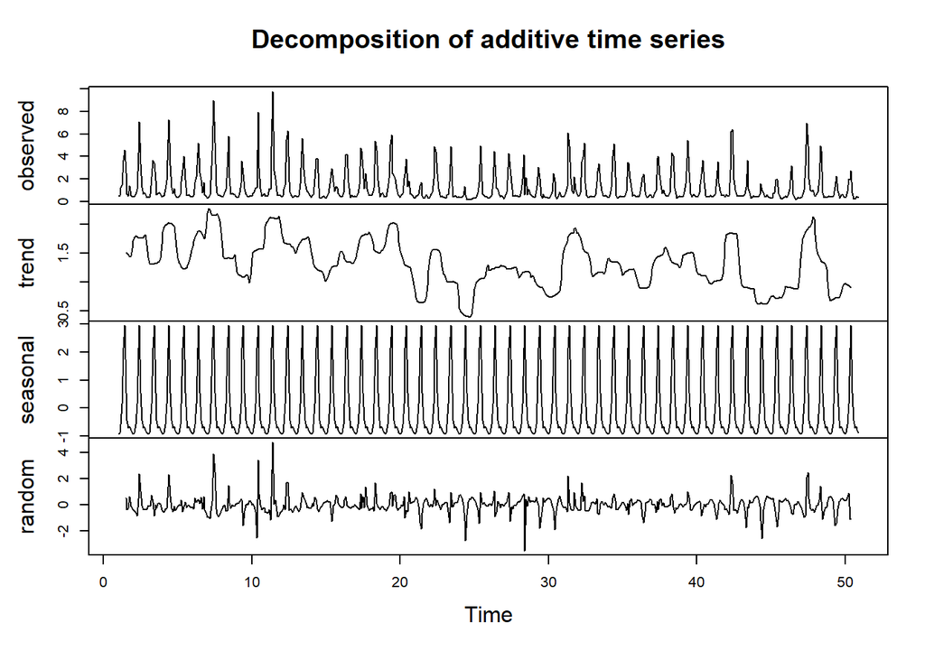

```r
plot(colorado_datos_original_ts_decompose)
```

### Analicemos los valores de la variable y

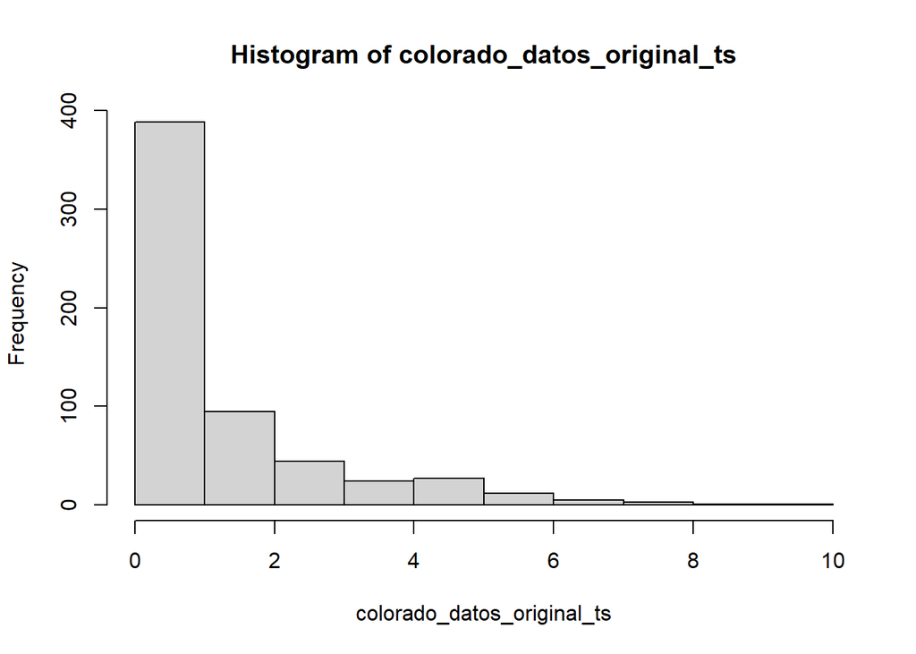

```r
hist(colorado_datos_original_ts)
```

```r
summary(colorado_datos_original_ts)
```

```
##    Min. 1st Qu.  Median    Mean 3rd Qu.    Max.
##   0.160   0.440   0.640   1.320   1.663   9.810
```

Se observa que la gran mayoria de los valores de la variable y están en el intervalo de [0,2] y que claramente la variable no sigue una distribución normal

#### Separamos el colorado_datos_original_ts en data sets train y test

Se tienen 600 datos mensuales, por lo que el train serpa de 576 datos, para que el test sea de 24 datos o 2 años

```r
# Split the data into training and testing sets


# Subset the data to keep rows from the beginning until train_end and all columns
colorado_datos_original_ts_train <- colorado_datos_original_ts[1:576]
head(colorado_datos_original_ts_train)
```

```
## [1] 0.46 0.53 1.24 1.48 3.69 4.57
```

```r
tail(colorado_datos_original_ts_train)
```

```
## [1] 0.77 0.35 0.39 0.38 0.44 0.45
```

```r
# Subset the data to keep rows from the beginning until train_end and all columns


colorado_datos_original_ts_test <- colorado_datos_original_ts[577:600]
head(colorado_datos_original_ts_test)
```

```
## [1] 0.39 0.39 0.42 0.52 1.26 2.26
```

```r
tail(colorado_datos_original_ts_test)
```

```
## [1] 0.80 0.25 0.24 0.42 0.42 0.34
```

#### Apliquemos un modelo de Simple Moving Average (SMA) a los datos_original

```r
# Load the TTR package
library(TTR)

colorado_datos_original_ts_SMA <- SMA(colorado_datos_original_ts, n=3)


colorado_datos_original_ts_SMA_pc <- SMA(colorado_datos_original_ts_train, n=3)



## datos_original_ts_SMA <- ma(datos_original_ts, oder=2, center=TRUE)
```

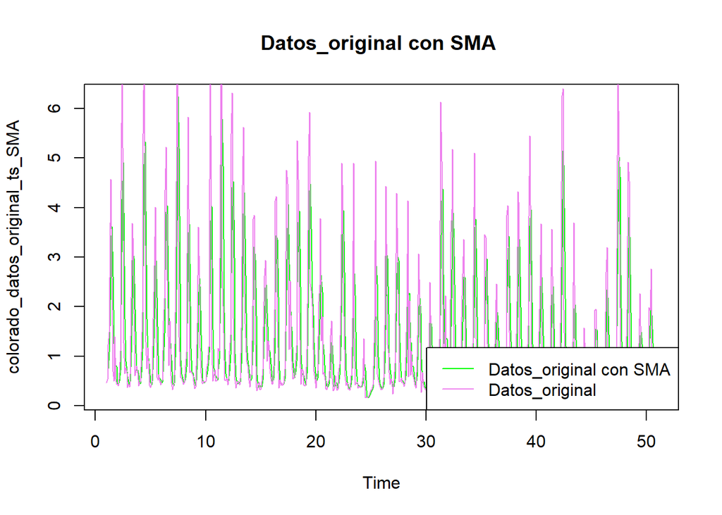

```r
plot(colorado_datos_original_ts_SMA, col = "green", main = "Datos_original con SMA ")
lines(colorado_datos_original_ts, col="violet")
legend("bottomright", legend = c("Datos_original con SMA", "Datos_original"), col = c("green", "violet"), lty = 1)
```

#### Calculo de predección con Simple Moving Average (SMA) de datos_original

```r
library(forecast)

forecast_colorado_datos_original_ts_SMA<-forecast(colorado_datos_original_ts_SMA_pc, h=24)
forecast_colorado_datos_original_ts_SMA
```

```
##     Point Forecast       Lo 80     Hi 80       Lo 95     Hi 95
## 577      0.4460390  0.17176624 0.7203118   0.0265750  0.865503
## 578      0.4687444  0.04907201 0.8884169  -0.1730891  1.110578
## 579      0.4914499 -0.06459614 1.0474959  -0.3589491  1.341849
## 580      0.5141553 -0.18041333 1.2087239  -0.5480957  1.576406
## 581      0.5368607 -0.30323024 1.3769516  -0.7479475  1.821669
## 582      0.5595661 -0.43614011 1.5552723  -0.9632352  2.082367
## 583      0.5822715 -0.58161344 1.7461565  -1.1977369  2.362280
## 584      0.6049769 -0.74191137 1.9518653  -1.4549110  2.664865
## 585      0.6276824 -0.91927634 2.1746411  -1.7381868  2.993552
## 586      0.6503878 -1.11603775 2.4168133  -2.0511269  3.351902
## 587      0.6730932 -1.33468133 2.6808677  -2.3975330  3.743719
## 588      0.6957986 -1.57790190 2.9694991  -2.7815262  4.173123
## 589      0.7185040 -1.84864865 3.2856567  -3.2076172  4.644625
## 590      0.7412095 -2.15016801 3.6325869  -3.6807708  5.163190
## 591      0.7639149 -2.48604641 4.0138761  -4.2064720  5.734302
## 592      0.7866203 -2.86025500 4.4334956  -4.7907942  6.364035
## 593      0.8093257 -3.27719739 4.8958488  -5.4404720  7.059123
## 594      0.8320311 -3.74176140 5.4058236  -6.1629809  7.827043
## 595      0.8547365 -4.25937570 5.9688488  -6.9666232  8.676096
## 596      0.8774420 -4.83607220 6.5909561  -7.8606239  9.615508
## 597      0.9001474 -5.47855491 7.2788497  -8.8552359 10.655531
## 598      0.9228528 -6.19427626 8.0399818  -9.9618568 11.807562
## 599      0.9455582 -6.99152167 8.8826381 -11.1931580 13.084274
## 600      0.9682636 -7.87950349 9.8160307 -12.5632285 14.499756
```

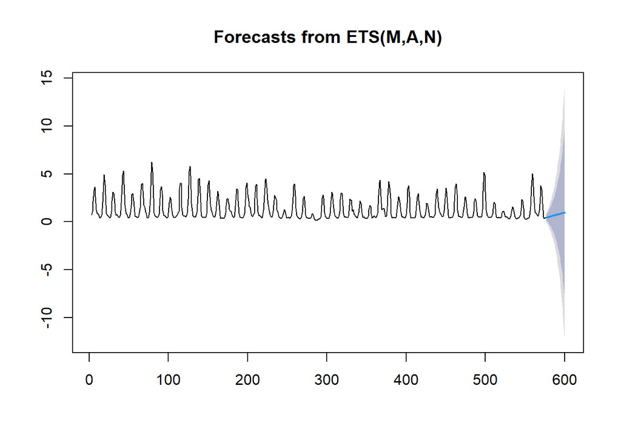

```r
plot(forecast_colorado_datos_original_ts_SMA)
```

#### Calculo de errror con Simple Moving Average (SMA) de datos_original

```r
library(forecast)

accuracy(forecast_colorado_datos_original_ts_SMA)
```

```
##                       ME      RMSE       MAE       MPE     MAPE    MASE
## Training set -0.06507301 0.7514686 0.5040933 -18.53777 39.65862 1.02539
##                   ACF1
## Training set 0.5826625
```

```r
# Load the TTR package
library(TTR)

colorado_datos_original_ts_WMA <- WMA(colorado_datos_original_ts, n = 3, wts = c(0.333, 0.333, 0.333))

colorado_datos_original_ts_WMA_pc <- WMA(colorado_datos_original_ts_train, n = 3, wts = c(0.333, 0.333, 0.333))
```

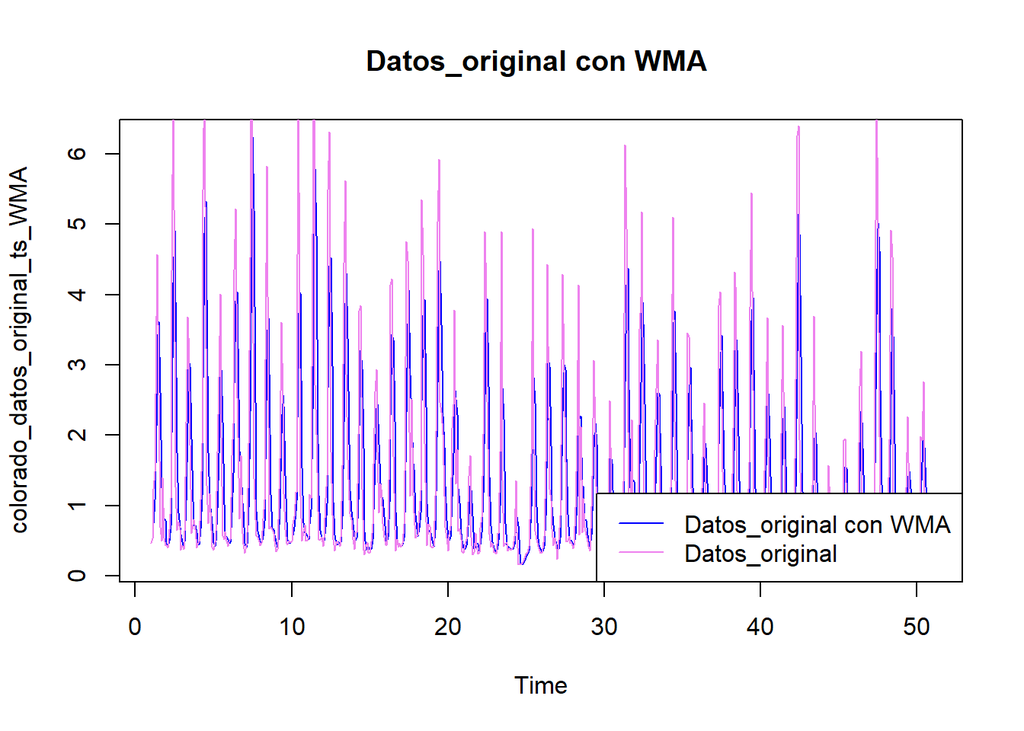

```r
plot(colorado_datos_original_ts_WMA, col = "blue", main = "Datos_original con WMA ")
lines(colorado_datos_original_ts, col="violet")
legend("bottomright", legend = c("Datos_original con WMA", "Datos_original"), col = c("blue", "violet"), lty = 1)
```

#### Calculo de predección con Weighted Moving Average (WMA) de datos_original

```r
library(forecast)

forecast_colorado_datos_original_ts_WMA<-forecast(colorado_datos_original_ts_WMA_pc, h=24)
forecast_colorado_datos_original_ts_WMA
```

```
##     Point Forecast       Lo 80     Hi 80       Lo 95     Hi 95
## 577      0.4460390  0.17176624 0.7203118   0.0265750  0.865503
## 578      0.4687444  0.04907201 0.8884169  -0.1730891  1.110578
## 579      0.4914499 -0.06459614 1.0474959  -0.3589491  1.341849
## 580      0.5141553 -0.18041333 1.2087239  -0.5480957  1.576406
## 581      0.5368607 -0.30323024 1.3769516  -0.7479475  1.821669
## 582      0.5595661 -0.43614011 1.5552723  -0.9632352  2.082367
## 583      0.5822715 -0.58161344 1.7461565  -1.1977369  2.362280
## 584      0.6049769 -0.74191137 1.9518653  -1.4549110  2.664865
## 585      0.6276824 -0.91927634 2.1746411  -1.7381868  2.993552
## 586      0.6503878 -1.11603775 2.4168133  -2.0511269  3.351902
## 587      0.6730932 -1.33468133 2.6808677  -2.3975330  3.743719
## 588      0.6957986 -1.57790190 2.9694991  -2.7815262  4.173123
## 589      0.7185040 -1.84864865 3.2856567  -3.2076172  4.644625
## 590      0.7412095 -2.15016801 3.6325869  -3.6807708  5.163190
## 591      0.7639149 -2.48604641 4.0138761  -4.2064720  5.734302
## 592      0.7866203 -2.86025500 4.4334956  -4.7907942  6.364035
## 593      0.8093257 -3.27719739 4.8958488  -5.4404720  7.059123
## 594      0.8320311 -3.74176140 5.4058236  -6.1629809  7.827043
## 595      0.8547365 -4.25937570 5.9688488  -6.9666232  8.676096
## 596      0.8774420 -4.83607220 6.5909561  -7.8606239  9.615508
## 597      0.9001474 -5.47855491 7.2788497  -8.8552359 10.655531
## 598      0.9228528 -6.19427626 8.0399818  -9.9618568 11.807562
## 599      0.9455582 -6.99152167 8.8826381 -11.1931580 13.084274
## 600      0.9682636 -7.87950349 9.8160307 -12.5632285 14.499756
```

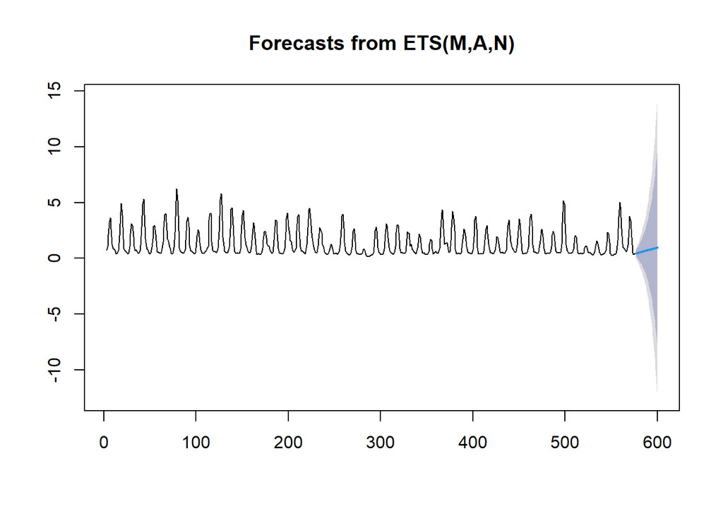

```r
plot(forecast_colorado_datos_original_ts_WMA)
```

#### Calculo de errror con Weighted Moving Average (WMA) de datos_original

```r
library(forecast)

accuracy(forecast_colorado_datos_original_ts_WMA)
```

```
##                       ME      RMSE       MAE       MPE     MAPE    MASE
## Training set -0.06507301 0.7514686 0.5040933 -18.53777 39.65862 1.02539
##                   ACF1
## Training set 0.5826625
```

## Ahora intentemos ajustar un ‘modelo lineal generalizado simple’ a los datos_original

Para ello vamos a construir una especie de “Variables dummy” de los meses del año

```r
tend <- c(1:600)

dim(tend)
```

```r
mes=c("ene","feb","mar","abr","may","jun","jul","ago","sep","oct","nov","dic")

rep_mes <- rep(mes,50)



colorado_datos_original_ts_train_frame <- data.frame(colorado_datos_original_ts_train,rep_mes[1:576],tend[1:576])
head(colorado_datos_original_ts_train_frame)
```

```
##   colorado_datos_original_ts_train rep_mes.1.576. tend.1.576.
## 1                             0.46            ene           1
## 2                             0.53            feb           2
## 3                             1.24            mar           3
## 4                             1.48            abr           4
## 5                             3.69            may           5
## 6                             4.57            jun           6
```

```r
tail(colorado_datos_original_ts_train_frame)
```

```
##     colorado_datos_original_ts_train rep_mes.1.576. tend.1.576.
## 571                             0.77            jul         571
## 572                             0.35            ago         572
## 573                             0.39            sep         573
## 574                             0.38            oct         574
## 575                             0.44            nov         575
## 576                             0.45            dic         576
```

```r
dim(colorado_datos_original_ts_train_frame)
```

```
## [1] 576   3
```

```r
colorado_datos_original_ts_train_frame$rep_mes <-colorado_datos_original_ts_train_frame$rep_mes.1.576.
colorado_datos_original_ts_train_frame$rep_mes.1.576. <- NULL
colorado_datos_original_ts_train_frame$tend <-colorado_datos_original_ts_train_frame$tend.1.576.
colorado_datos_original_ts_train_frame$tend.1.576. <- NULL

colorado_datos_original_ts_train_frame
```

```
##     colorado_datos_original_ts_train rep_mes tend
## 1                               0.46     ene    1
## 2                               0.53     feb    2
## 3                               1.24     mar    3
## 4                               1.48     abr    4
## 5                               3.69     may    5
## 6                               4.57     jun    6
## 7                               2.58     jul    7
## 8                               0.69     ago    8
## 9                               0.50     sep    9
## 10                              1.40     oct   10
## 11                              0.54     nov   11
## 12                              0.43     dic   12
## 13                              0.43     ene   13
## 14                              0.40     feb   14
```

[output cut: 562 more lines]

#### Se ‘entrena’ (en este caso, se define) al modelo lineal ‘simple’ con los datos de train

```r
modelo_lineal_simple1_colorado_datos_original <- glm (colorado_datos_original_ts_train ~  rep_mes + tend, data=colorado_datos_original_ts_train_frame, family = gaussian(link = identity))
modelo_lineal_simple1_colorado_datos_original
```

```
##
## Call:  glm(formula = colorado_datos_original_ts_train ~ rep_mes + tend,
##     family = gaussian(link = identity), data = colorado_datos_original_ts_train_frame)
##
## Coefficients:
## (Intercept)   rep_mesago   rep_mesdic   rep_mesene   rep_mesfeb   rep_mesjul
##   1.7638141   -0.5852409   -1.0311069   -1.0802360   -1.0227962    0.4202360
##  rep_mesjun   rep_mesmar   rep_mesmay   rep_mesnov   rep_mesoct   rep_messep
##   2.8636295   -0.7255648    2.0580648   -0.9208383   -0.8041114   -0.8448845
##        tend
##  -0.0009814
##
## Degrees of Freedom: 575 Total (i.e. Null);  563 Residual
## Null Deviance:       1273
## Residual Deviance: 357.7     AIC: 1388
```

Se obtiene el summary y plot del modelo lineal ‘simple’

```r
summary(modelo_lineal_simple1_colorado_datos_original)
```

```
##
## Call:
## glm(formula = colorado_datos_original_ts_train ~ rep_mes + tend,
##     family = gaussian(link = identity), data = colorado_datos_original_ts_train_frame)
##
## Deviance Residuals:
##     Min       1Q   Median       3Q      Max
## -3.7236  -0.2384  -0.0524   0.1989   5.3062
##
## Coefficients:
##               Estimate Std. Error t value Pr(>|t|)
## (Intercept)  1.7638141  0.1284489  13.732  < 2e-16 ***
## rep_mesago  -0.5852409  0.1626968  -3.597  0.00035 ***
## rep_mesdic  -1.0311069  0.1627027  -6.337 4.79e-10 ***
## rep_mesene  -1.0802360  0.1626959  -6.640 7.42e-11 ***
## rep_mesfeb  -1.0227962  0.1626953  -6.287 6.51e-10 ***
## rep_mesjul   0.4202360  0.1626959   2.583  0.01005 *
## rep_mesjun   2.8636295  0.1626953  17.601  < 2e-16 ***
## rep_mesmar  -0.7255648  0.1626949  -4.460 9.91e-06 ***
## rep_mesmay   2.0580648  0.1626949  12.650  < 2e-16 ***
## rep_mesnov  -0.9208383  0.1627008  -5.660 2.42e-08 ***
## rep_mesoct  -0.8041114  0.1626992  -4.942 1.02e-06 ***
## rep_messep  -0.8448845  0.1626979  -5.193 2.90e-07 ***
## tend        -0.0009814  0.0001998  -4.913 1.18e-06 ***
## ---
## Signif. codes:  0 '***' 0.001 '**' 0.01 '*' 0.05 '.' 0.1 ' ' 1
##
## (Dispersion parameter for gaussian family taken to be 0.6352705)
##
##     Null deviance: 1272.82  on 575  degrees of freedom
## Residual deviance:  357.66  on 563  degrees of freedom
## AIC: 1388.1
##
## Number of Fisher Scoring iterations: 2
```

Se puede observar que el modelo lineal simple resultante otorga valores estadisticamente significativos para el caso del intercepto y los “meses dummy” de: agost, dic, ene, feb, jul, jun , mar, may, nov , oct y sept con un valor de criterio de AIC de 1388

Vamos a proceder a plotear los residuos de mi modelo lineal

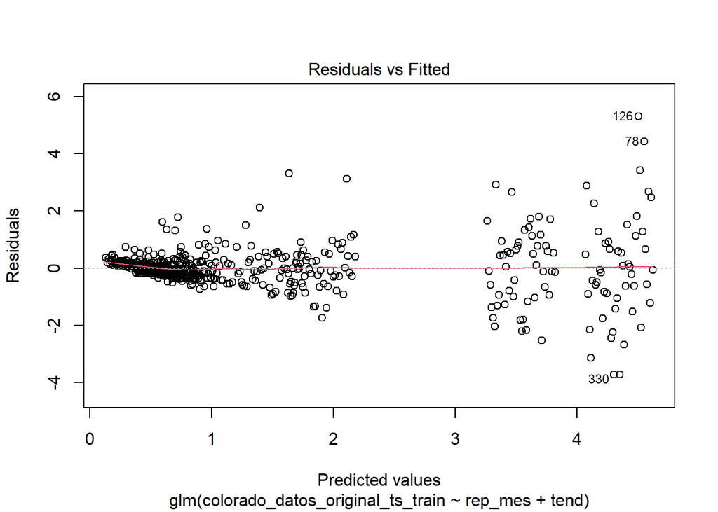

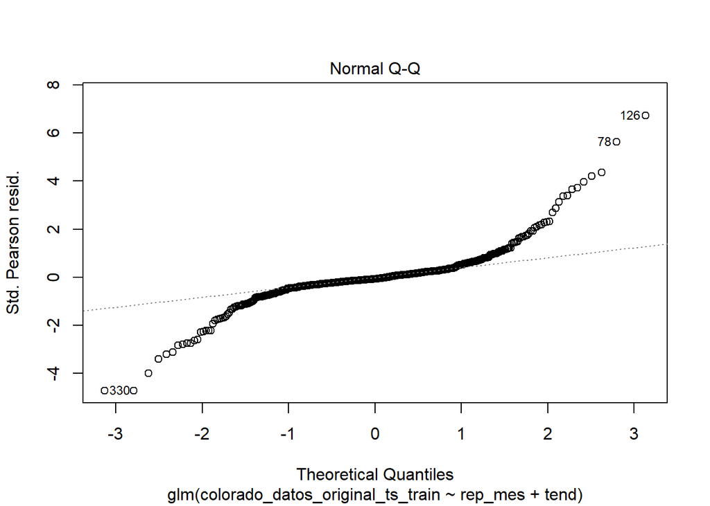

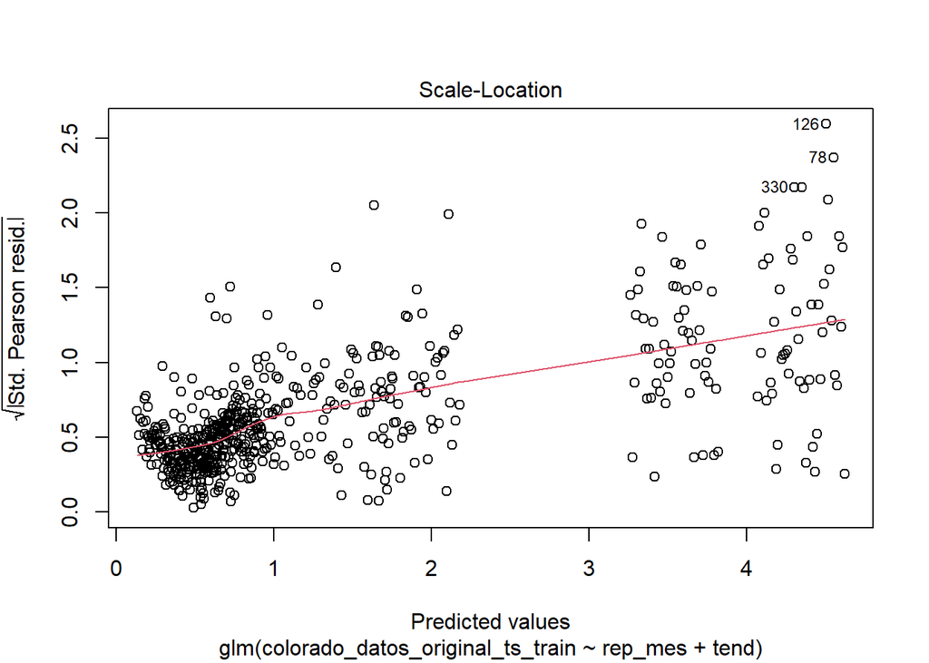

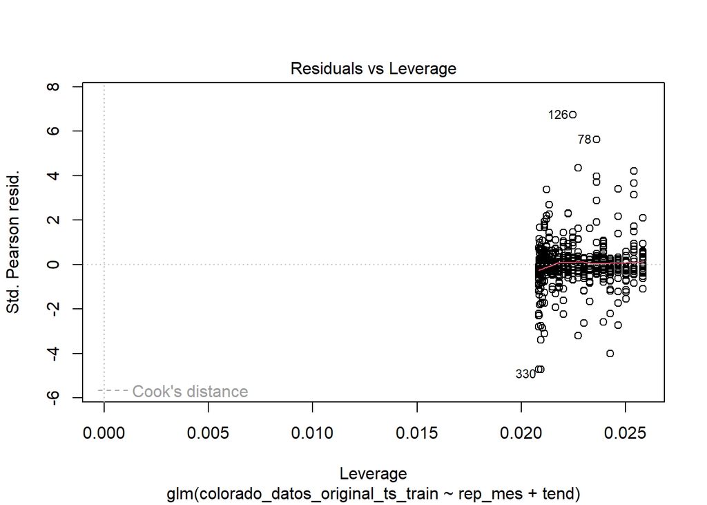

```r
plot(modelo_lineal_simple1_colorado_datos_original)
```

Se observa que los reiduos no tienen pendiente definida, tendencia o siguen un patron establecido, sin embargo, tampoco se podría asumir que los errores son correctos pues para algunos valores el error es muy pequeño y para otros es muy grande lo que podría indicar que hal alguna variable o relación que no se está tomando en cuenta.

#### Testeo del ‘modelo lineal generalizado simple’ haciendo la predición de los datos de test

```r
colorado_datos_original_ts_test_frame <- data.frame(colorado_datos_original_ts_test,rep_mes[577:600],tend[577:600])
head(colorado_datos_original_ts_test_frame)
```

```
##   colorado_datos_original_ts_test rep_mes.577.600. tend.577.600.
## 1                            0.39              ene           577
## 2                            0.39              feb           578
## 3                            0.42              mar           579
## 4                            0.52              abr           580
## 5                            1.26              may           581
## 6                            2.26              jun           582
```

```r
tail(colorado_datos_original_ts_test_frame)
```

```
##    colorado_datos_original_ts_test rep_mes.577.600. tend.577.600.
## 19                            0.80              jul           595
## 20                            0.25              ago           596
## 21                            0.24              sep           597
## 22                            0.42              oct           598
## 23                            0.42              nov           599
## 24                            0.34              dic           600
```

```r
dim(colorado_datos_original_ts_test_frame)
```

```
## [1] 24  3
```

```r
colorado_datos_original_ts_test_frame$rep_mes <-colorado_datos_original_ts_test_frame$rep_mes.577.600.
colorado_datos_original_ts_test_frame$rep_mes.577.600. <- NULL
colorado_datos_original_ts_test_frame$tend <-colorado_datos_original_ts_test_frame$tend.577.600.
colorado_datos_original_ts_test_frame$tend.577.600. <- NULL

colorado_datos_original_ts_test_frame
```

```
##    colorado_datos_original_ts_test rep_mes tend
## 1                             0.39     ene  577
## 2                             0.39     feb  578
## 3                             0.42     mar  579
## 4                             0.52     abr  580
## 5                             1.26     may  581
## 6                             2.26     jun  582
## 7                             0.96     jul  583
## 8                             0.52     ago  584
## 9                             0.30     sep  585
## 10                            0.62     oct  586
## 11                            0.61     nov  587
## 12                            0.43     dic  588
## 13                            0.37     ene  589
## 14                            0.39     feb  590
## 15                            0.92     mar  591
## 16                            1.98     abr  592
## 17                            1.93     may  593
## 18                            2.76     jun  594
## 19                            0.80     jul  595
## 20                            0.25     ago  596
## 21                            0.24     sep  597
## 22                            0.42     oct  598
## 23                            0.42     nov  599
## 24                            0.34     dic  600
```

#### Calculo de predicción del ‘modelo lineal generalizado simple’ para los datos_original

```r
prediccion_modelo_lineal_simple1_colorado_datos_original <- predict(modelo_lineal_simple1_colorado_datos_original, newdata = colorado_datos_original_ts_test_frame, se.fit = TRUE)


prediccion_modelo_lineal_simple1_colorado_datos_original
```

```
## $fit
##         1         2         3         4         5         6         7         8
## 0.1172928 0.1737511 0.4700011 1.1945844 3.2516678 4.0562511 1.6118761 0.6054178
##         9        10        11        12        13        14        15        16
## 0.3447928 0.3845844 0.2668761 0.1556261 0.1055156 0.1619739 0.4582239 1.1828073
##        17        18        19        20        21        22        23        24
## 3.2398906 4.0444739 1.6000989 0.5936406 0.3330156 0.3728073 0.2550989 0.1438489
##
## $se.fit
##         1         2         3         4         5         6         7         8
## 0.1291677 0.1291677 0.1291677 0.1291677 0.1291677 0.1291677 0.1291677 0.1291677
##         9        10        11        12        13        14        15        16
## 0.1291677 0.1291677 0.1291677 0.1291677 0.1302752 0.1302752 0.1302752 0.1302752
##        17        18        19        20        21        22        23        24
## 0.1302752 0.1302752 0.1302752 0.1302752 0.1302752 0.1302752 0.1302752 0.1302752
##
## $residual.scale
## [1] 0.7970386
```

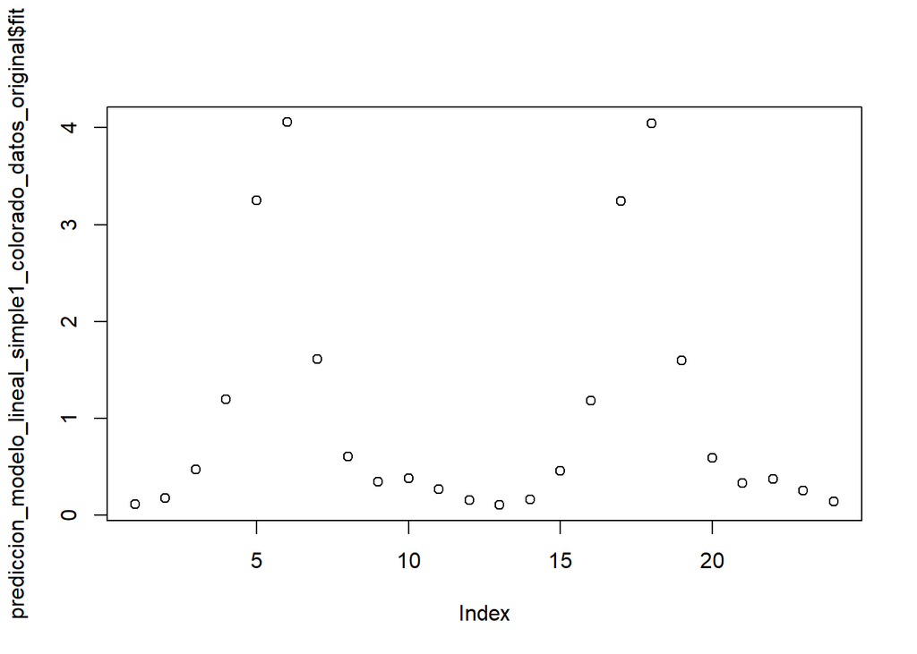

```r
plot(prediccion_modelo_lineal_simple1_colorado_datos_original$fit)
```

#### Calculo de errores del ‘modelo lineal generalizado simple’ para los datos_original

```r
accuracy(colorado_datos_original_ts_test , prediccion_modelo_lineal_simple1_colorado_datos_original$fit)
```

```
##                 ME      RMSE       MAE       MPE     MAPE
## Test set 0.2343382 0.7534868 0.5261377 -43.67181 81.02142
```

El MAPE del modelo lineal generalizado simple es mayor que el de los métodos de SMA y WMA

## Modelo SARIMA para Datos_original

#### Determinación de ACF & PACF para el caso de la colorado_data_original (SIN ESTACIONALIZAR)

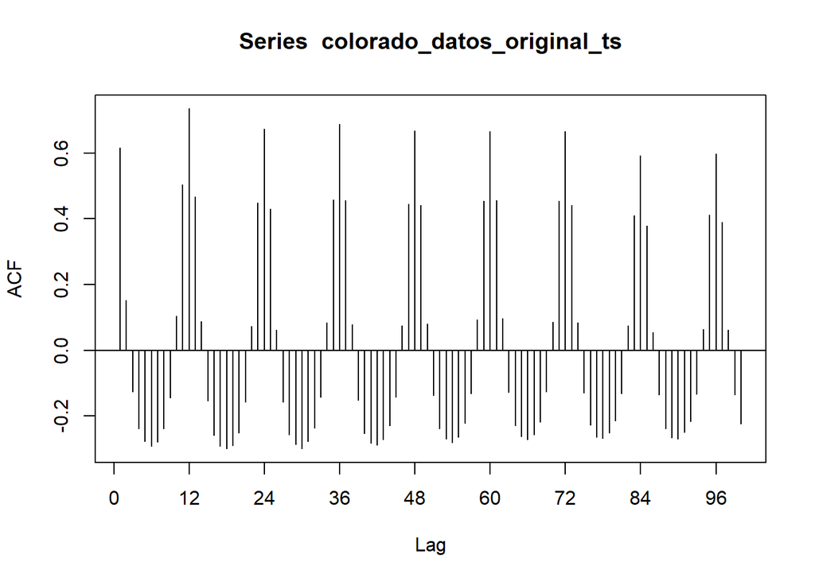

```r
#install.packages("forecast")
library(forecast)

#par(mfrow=c(2,1))

acf_colorado_datos_original_ts_sin_diferenciar <- Acf(colorado_datos_original_ts, lag.max = 100, ci.type = "ma")
```

```r
acf_colorado_datos_original_ts_sin_diferenciar
```

```
##
## Autocorrelations of series 'colorado_datos_original_ts', by lag
##
##      0      1      2      3      4      5      6      7      8      9     10
##  1.000  0.616  0.152 -0.125 -0.237 -0.277 -0.291 -0.279 -0.239 -0.144  0.104
##     11     12     13     14     15     16     17     18     19     20     21
##  0.504  0.735  0.467  0.087 -0.153 -0.258 -0.291 -0.299 -0.290 -0.251 -0.157
##     22     23     24     25     26     27     28     29     30     31     32
##  0.074  0.449  0.672  0.430  0.063 -0.158 -0.257 -0.286 -0.298 -0.277 -0.236
##     33     34     35     36     37     38     39     40     41     42     43
## -0.142  0.084  0.459  0.689  0.456  0.079 -0.151 -0.253 -0.283 -0.288 -0.270
##     44     45     46     47     48     49     50     51     52     53     54
## -0.229 -0.141  0.075  0.444  0.668  0.442  0.080 -0.137 -0.238 -0.270 -0.280
##     55     56     57     58     59     60     61     62     63     64     65
## -0.263 -0.221 -0.131  0.093  0.455  0.665  0.457  0.097 -0.128 -0.229 -0.263
##     66     67     68     69     70     71     72     73     74     75     76
## -0.270 -0.257 -0.217 -0.127  0.086  0.455  0.665  0.442  0.084 -0.129 -0.227
##     77     78     79     80     81     82     83     84     85     86     87
## -0.264 -0.268 -0.250 -0.213 -0.130  0.074  0.409  0.593  0.378  0.054 -0.135
##     88     89     90     91     92     93     94     95     96     97     98
## -0.238 -0.266 -0.269 -0.249 -0.216 -0.132  0.064  0.412  0.597  0.390  0.062
##     99    100
## -0.134 -0.224
```

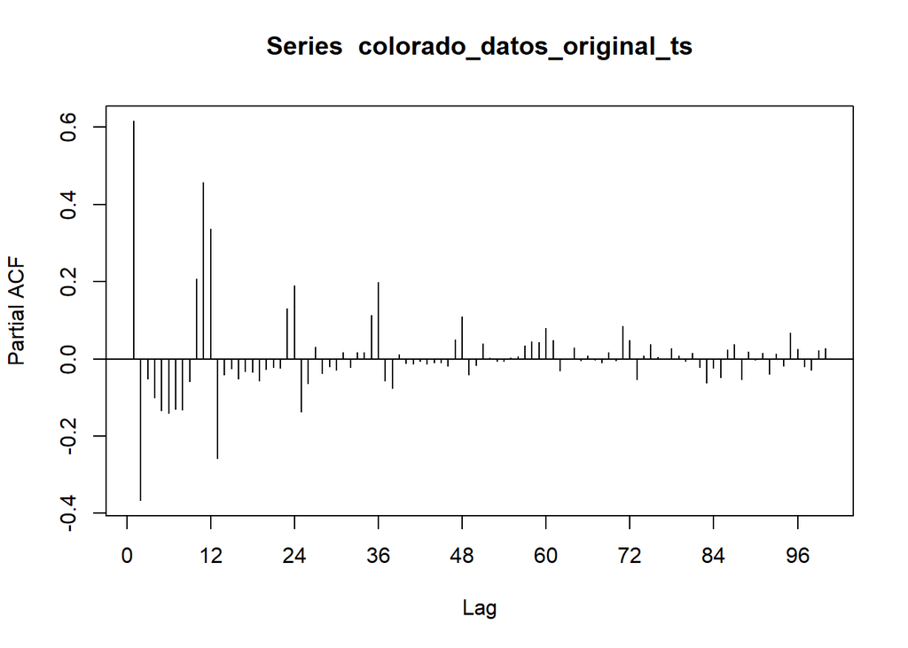

```r
pacf_datos_colorado_original_ts_sin_diferenciar <- Pacf(colorado_datos_original_ts, lag.max = 100, ci.type = "ma")
```

```r
pacf_datos_colorado_original_ts_sin_diferenciar
```

```
##
## Partial autocorrelations of series 'colorado_datos_original_ts', by lag
##
##      1      2      3      4      5      6      7      8      9     10     11
##  0.616 -0.366 -0.051 -0.099 -0.133 -0.141 -0.131 -0.132 -0.059  0.208  0.457
##     12     13     14     15     16     17     18     19     20     21     22
##  0.337 -0.258 -0.042 -0.025 -0.052 -0.031 -0.033 -0.057 -0.027 -0.022 -0.024
##     23     24     25     26     27     28     29     30     31     32     33
##  0.131  0.189 -0.137 -0.064  0.031 -0.037 -0.019 -0.029  0.017 -0.022  0.017
##     34     35     36     37     38     39     40     41     42     43     44
##  0.017  0.113  0.199 -0.056 -0.076  0.012 -0.011 -0.013 -0.005 -0.012 -0.010
##     45     46     47     48     49     50     51     52     53     54     55
## -0.008 -0.019  0.050  0.110 -0.040 -0.017  0.040  0.003 -0.005 -0.005  0.003
##     56     57     58     59     60     61     62     63     64     65     66
##  0.006  0.035  0.044  0.042  0.080  0.048 -0.031  0.001  0.030 -0.004  0.007
##     67     68     69     70     71     72     73     74     75     76     77
## -0.002 -0.009  0.016 -0.004  0.084  0.048 -0.054  0.008  0.037  0.005  0.000
##     78     79     80     81     82     83     84     85     86     87     88
##  0.028  0.008 -0.005  0.015 -0.021 -0.062 -0.023 -0.048  0.024  0.037 -0.053
##     89     90     91     92     93     94     95     96     97     98     99
##  0.019 -0.002  0.015 -0.039  0.014 -0.017  0.068  0.025 -0.020 -0.029  0.022
##    100
##  0.028
```

La función ACF de la serie colorado, nos muestra claramente la estacionalidad marcadísima cada 12 meses y como en general No tiene una forma de decaimitno constant. Hagamos una prueba de estacionariedad

#### Se lleva a cabo el tet de Dickey-Fulley (Ho: Serie no estacionaria) a la serie de datos_original

```r
# Install and load the "urca" package
#install.packages("urca")
library(urca)

# Perform ADF test for stationarity
adf_test_datos_colorado_original_ts <- ur.df(colorado_datos_original_ts)

# Print the ADF test results
summary(adf_test_datos_colorado_original_ts)
```

```
##
## ###############################################
## # Augmented Dickey-Fuller Test Unit Root Test #
## ###############################################
##
## Test regression none
##
##
## Call:
## lm(formula = z.diff ~ z.lag.1 - 1 + z.diff.lag)
##
## Residuals:
##     Min      1Q  Median      3Q     Max
## -5.6853  0.0484  0.1766  0.4990  7.0715
##
## Coefficients:
##            Estimate Std. Error t value Pr(>|t|)
## z.lag.1    -0.26176    0.02592 -10.099  < 2e-16 ***
## z.diff.lag  0.23500    0.03981   5.903 6.01e-09 ***
## ---
## Signif. codes:  0 '***' 0.001 '**' 0.01 '*' 0.05 '.' 0.1 ' ' 1
##
## Residual standard error: 1.185 on 596 degrees of freedom
## Multiple R-squared:  0.1554, Adjusted R-squared:  0.1525
## F-statistic: 54.82 on 2 and 596 DF,  p-value: < 2.2e-16
##
##
## Value of test-statistic is: -10.0989
##
## Critical values for test statistics:
##       1pct  5pct 10pct
## tau1 -2.58 -1.95 -1.62
```

Se observa como el valor p de la prueva DF de estacioriedad fue menor a 0.05 por lo tanto se rechaza Ho que indicaba que la serie no era estacionaria y se acepta H1

Con base en las gráficas de ACF y PACF se decide probar un modleo ARIMA (1,0,2)

#### Ajustae y predicicon de Demanda_electrico con modelo ARIMA

```r
#install.packages("astsa")
library(astsa)
# Fit the SARIMA model
ARIMA_1_0_2_colorado_datos_original <- astsa::sarima(colorado_datos_original_ts_train , p=1, d=0, q=2)
```

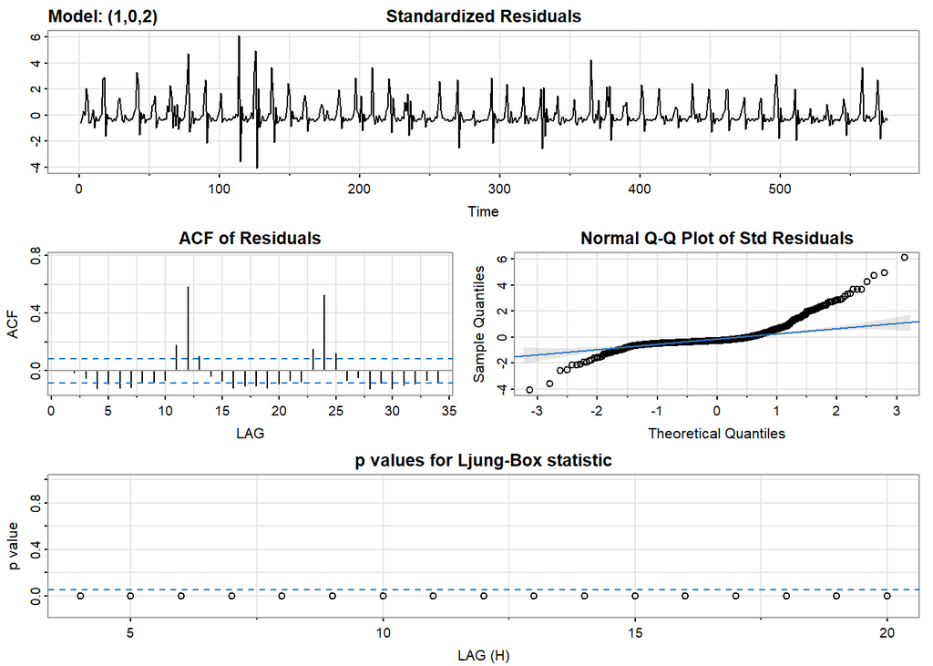

```r
# Print the model summary
summary(ARIMA_1_0_2_colorado_datos_original)
```

```
##                    Length Class  Mode
## fit                14     Arima  list
## degrees_of_freedom  1     -none- numeric
## ttable             16     -none- numeric
## AIC                 1     -none- numeric
## AICc                1     -none- numeric
## BIC                 1     -none- numeric
```

#### Calculo de predicción del ARIMA para los datos_original

```r
# Get the predictors


pred_ARIMA_1_0_2_colorado_datos_original <- sarima.for(colorado_datos_original_ts_train, n.ahead=24,1,0,2)
```

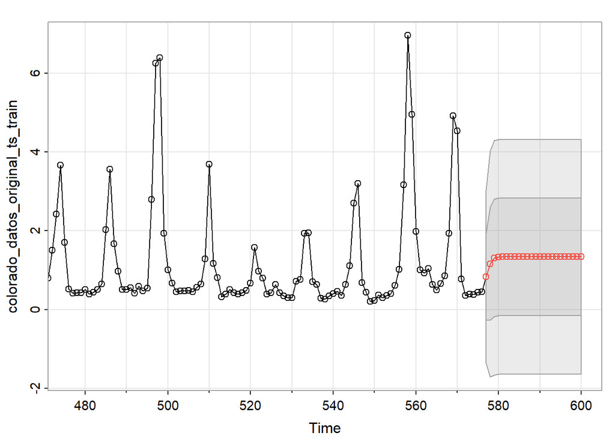

```r
pred_ARIMA_1_0_2_colorado_datos_original
```

```
## $pred
## Time Series:
## Start = 577
## End = 600
## Frequency = 1
##  [1] 0.8326951 1.1590375 1.3127157 1.3350674 1.3383184 1.3387912 1.3388600
##  [8] 1.3388700 1.3388714 1.3388717 1.3388717 1.3388717 1.3388717 1.3388717
## [15] 1.3388717 1.3388717 1.3388717 1.3388717 1.3388717 1.3388717 1.3388717
## [22] 1.3388717 1.3388717 1.3388717
##
## $se
## Time Series:
## Start = 577
## End = 600
## Frequency = 1
##  [1] 1.100840 1.435699 1.488461 1.489557 1.489580 1.489581 1.489581 1.489581
##  [9] 1.489581 1.489581 1.489581 1.489581 1.489581 1.489581 1.489581 1.489581
## [17] 1.489581 1.489581 1.489581 1.489581 1.489581 1.489581 1.489581 1.489581
```

```r
pred_ARIMA_1_0_2_colorado_datos_original$pred
```

```
## Time Series:
## Start = 577
## End = 600
## Frequency = 1
##  [1] 0.8326951 1.1590375 1.3127157 1.3350674 1.3383184 1.3387912 1.3388600
##  [8] 1.3388700 1.3388714 1.3388717 1.3388717 1.3388717 1.3388717 1.3388717
## [15] 1.3388717 1.3388717 1.3388717 1.3388717 1.3388717 1.3388717 1.3388717
## [22] 1.3388717 1.3388717 1.3388717
```

#### Calculo de errores del modelo ARIMA para los datos_original

```r
accuracy(colorado_datos_original_ts_test ,pred_ARIMA_1_0_2_colorado_datos_original$pred )
```

```
##                 ME      RMSE       MAE      MPE     MAPE     ACF1 Theil's U
## Test set 0.4965126 0.8425011 0.7943954 38.35574 60.60488 0.537948  7.667554
```

El MAPE del modelo ARIMA 1,0,2 es mayor que el de los métodos de SMA y WMA, pero menor que el del método lineal generalizado simple

#### Ajustae y predicicon de Demanda_original con modelo SARIMA + PDQ S

#### Calculo de predicción del SARIMA PDQ S para los datos_original

```r
library(forecast)

# Fit the SARIMA model
SARIMA_colorado_datos_original <- Arima(colorado_datos_original_ts_train, order = c(1, 0, 2), seasonal = list(order = c(0, 1, 1), period = 12))

# Forecast for the next 12 periods
forecast_SARIMA_colorado_datos_original <- forecast(SARIMA_colorado_datos_original, h = 24)

# Print the forecasted values
print(forecast_SARIMA_colorado_datos_original)
```

```
##     Point Forecast      Lo 80    Hi 80       Lo 95    Hi 95
## 577      0.4217232 -0.4899283 1.333375 -0.97252740 1.815974
## 578      0.4504250 -0.5581566 1.459007 -1.09206739 1.992917
## 579      0.6777955 -0.3532202 1.708811 -0.89900695 2.254598
## 580      1.3267953  0.2910621 2.362529 -0.25722198 2.910813
## 581      3.2207851  2.1840494 4.257521  1.63523470 4.806336
## 582      3.9727465  2.9357973 5.009696  2.38686955 5.558623
## 583      1.6868360  0.6498413 2.723831  0.10088949 3.272782
## 584      0.8052850 -0.2317193 1.842289 -0.78067625 2.391246
## 585      0.4892163 -0.5477901 1.526223 -1.09674812 2.075181
## 586      0.5292895 -0.5077174 1.566296 -1.05667563 2.115255
## 587      0.5380767 -0.4989303 1.575084 -1.04788860 2.124042
## 588      0.4462669 -0.5907400 1.483274 -1.13969832 2.032232
## 589      0.4198930 -0.6233718 1.463158 -1.17564279 2.015429
## 590      0.4487537 -0.5959073 1.493415 -1.14891746 2.046425
## 591      0.6770240 -0.3679799 1.722028 -0.92117164 2.275220
## 592      1.3264392  0.2813622 2.371516 -0.27186821 2.924747
## 593      3.2206207  2.1755281 4.265713  1.62228951 4.818952
## 594      3.9726706  2.9275746 5.017766  2.37433429 5.571007
## 595      1.6868009  0.6417043 2.731898  0.08846356 3.285138
## 596      0.8052689 -0.2398279 1.850366 -0.79306873 2.403606
## 597      0.4892089 -0.5558880 1.534306 -1.10912879 2.087547
## 598      0.5292860 -0.5158108 1.574383 -1.06905162 2.127624
## 599      0.5380751 -0.5070218 1.583172 -1.06026259 2.136413
## 600      0.4462662 -0.5988306 1.491363 -1.15207142 2.044604
```

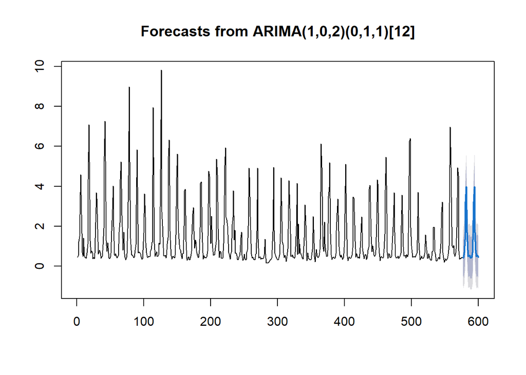

```r
plot(forecast_SARIMA_colorado_datos_original)
```

Se observa claramente como los modelos SARIMA son capaces de tomar encuenta la estacionalidad de la data y aplicarla a los pronósticos

```r
forecast_SARIMA_colorado_datos_original$mean
```

```
## Time Series:
## Start = 577
## End = 600
## Frequency = 1
##  [1] 0.4217232 0.4504250 0.6777955 1.3267953 3.2207851 3.9727465 1.6868360
##  [8] 0.8052850 0.4892163 0.5292895 0.5380767 0.4462669 0.4198930 0.4487537
## [15] 0.6770240 1.3264392 3.2206207 3.9726706 1.6868009 0.8052689 0.4892089
## [22] 0.5292860 0.5380751 0.4462662
```

#### Calculo de errores del Datos_orignal con SARIMA + PDQ S

```r
accuracy(colorado_datos_original_ts_test ,forecast_SARIMA_colorado_datos_original$mean )
```

```
##                 ME     RMSE       MAE      MPE     MAPE      ACF1 Theil's U
## Test set 0.4010645 0.735464 0.4893287 23.47459 33.11338 0.5835718 0.9367445
```

El mejor MAPE obtenido al momento para el caso de colorado es con el modelos SARIMA(1,0,2)[0,1,1]con S= 12